# Introduction to Machine Learning

Rafael A. Irizarry

### Artificial Intelligence

AI algorithms implement rules derived from theory or first principles

- Chess playing computers
- Auto-pilot airplanes
- Heat guided missiles

In contrast, Machine Learning uses data to train algorithms

### Machine Learning Examples

- Hand writing detection implemented by the postal service
- Speech recognition (Siri)
- Movie and other recommendation systems
- Predicting hospitalization days from claims
- Spam detectors

### General Set-up

We want to be able to predict an outcome based on features:

| outcome | feature_1 | feature_2 | feature_3 | feature_4 | feature_5 |
| --- | --- | --- | --- | --- | --- |
| ? | X_1 | X_2 | X_3 | X_4 | X_5 |

We want a function \( \,f \) that takes the \( X\mbox{s} \) and predicts an outcome.

### General Set-up

Collect data for which we know outcome to build a model:

| outcome | feature_1 | feature_2 | feature_3 | feature_4 | feature_5 |
| --- | --- | --- | --- | --- | --- |
| Y_1 | X_1,1 | X_1,2 | X_1,3 | X_1,4 | X_1,5 |
| Y_2 | X_2,1 | X_2,2 | X_2,3 | X_2,4 | X_2,5 |
| Y_3 | X_3,1 | X_3,2 | X_3,3 | X_3,4 | X_3,5 |
| Y_4 | X_4,1 | X_4,2 | X_4,3 | X_4,4 | X_4,5 |
| Y_5 | X_5,1 | X_5,2 | X_5,3 | X_5,4 | X_5,5 |
| Y_6 | X_6,1 | X_6,2 | X_6,3 | X_6,4 | X_6,5 |
| Y_7 | X_7,1 | X_7,2 | X_7,3 | X_7,4 | X_7,5 |
| Y_8 | X_8,1 | X_8,2 | X_8,3 | X_8,4 | X_8,5 |
| Y_9 | X_9,1 | X_9,2 | X_9,3 | X_9,4 | X_9,5 |
| Y_10 | X_10,1 | X_10,2 | X_10,3 | X_10,4 | X_10,5 |

### Assessment

Which of these outcome are continuous and which categorical?

1. Digit reader
2. Movie recommendations
3. Spam filter
4. Predicting hospitalization days
5. Siri

### Writing Detection

[figure not shown]

### Training Data

Images are digitized into \( 28 \times 28 \) pixels:

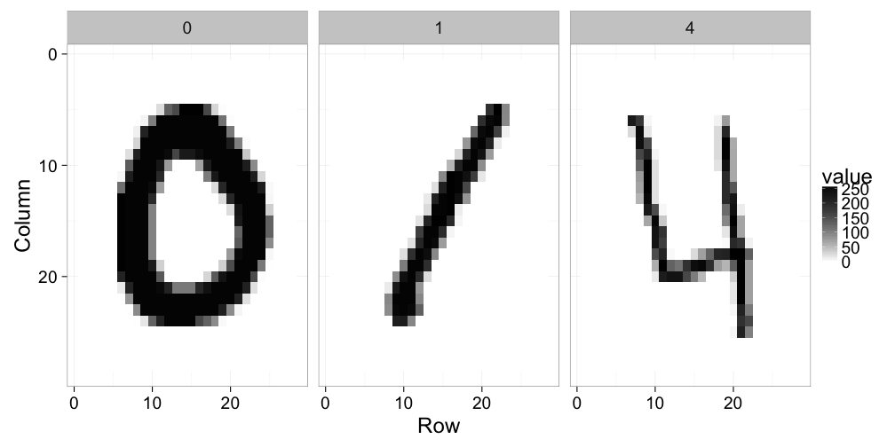

### Assessment

How many features are available to us for prediction?

### The 784 features

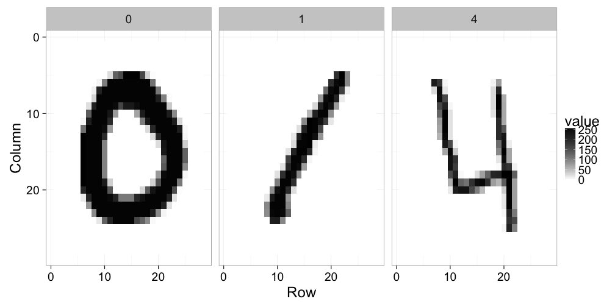

### The 784 features

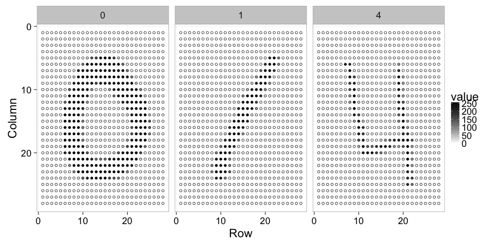

### Notation

For observation \( i \) we define the vector of \( p \) features

\[ \mathbf{X}_i = (X_{i,1},\dots,X_{i,p}) \]

For the digits example \( \,j=1,\dots,p \mbox{ with } p=784 \)

\( X_{i,j} \) is the intensity of j-th feature

### Conditional Probabilities

- For categorical problems \( Y \) can be one of \( K \) classes.
- \( Y \) can be \( 1, 2, \dots, \) or \( K \)
- To make a rational prediction we need

\[ f_k(x) \equiv \mbox{Pr}(Y=k \mid \mathbf{X}=\mathbf{x}), k=1,\dots,K \]

- \( f_k(x) \) is called a prediction rule
- Machine Learning is all about **estimating** \( \,f_k(x) \)

### Binary Data

- Many examples are binary. Example: fraud detection
- In this case we use \( k=0,1 \)

For binary data

\[ \mbox{Pr}(Y=1 \mid \mathbf{X}=\mathbf{x}) \]

is the proportion of 1s in the \( \mathbf{X}=\mathbf{x} \) stratum

### Conditional Expectations

Many of the algorithms can be applied to both categorical and continuous because if \( Y \) is binary:

\[ f(x) \equiv \mbox{E}(Y \mid \mathbf{X}=\mathbf{x})=\mbox{Pr}(Y=1 \mid \mathbf{X}=\mathbf{x}) \].

For continuous problems we estimate \( \mbox{E}(Y \mid \mathbf{X}=\mathbf{x}) \) because it minimizes

\[ \mbox{E}\{ (\hat{Y} - Y)^2 \mid \mathbf{X}=\mathbf{x} \} \]

### Assessment

For the father and son heights round each father height to the nearest integer to form a predictor:

```r
data(father.son,package="UsingR")
X <- round(father.son$fheight)
```

What is you prediction for son's height when \( X=66 \)? Hint: use conditional expectation.

### Loss Function

We are tasked with developing a Machine Learning algorithm that given the height of the father \( X \) predicts the height of the son \( Y \).

How will we be judged?

We need to choose a *loss function*

A typical one is:

\[ (Y - \hat{Y})^2 \]

### Loss Function

Because we consider \( Y \) is a random variable:

\[ \mbox{E}\left\{ (Y - \hat{Y})^2 \right\} \]

We can show mathematically, that the \( \hat{Y} \) that minimizes this quantity for an \( X=x \) is the conditional expectation

\[ \mbox{E}\left( Y \mid X=x\right) \]

### Regression for Prediction

We are provided a training set to build a model:

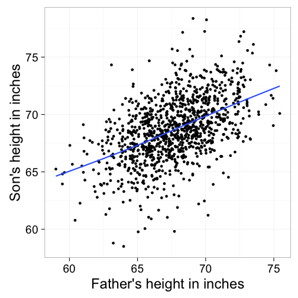

### Assessment

1. What is the prediction rule to predict son's height from father's height? Hint: We know that the regression line provides and estimate of \( \mbox{E}\left( Y \mid X=x\right) \)
2. What is the prediction rule to predict father's height from son's height?

### Binary Outcomes

Given a bio260 students height predict their gender.

We have [data](https://raw.githubusercontent.com/datasciencelabs/data/master/bio260-heights.csv):

| time | gender | height |
| --- | --- | --- |
| 1/25/2016 8:15:15 | Female | 63.00 |
| 1/25/2016 8:15:21 | Female | 62.00 |
| 1/25/2016 8:15:25 | Male | 69.00 |
| 1/25/2016 8:15:29 | Female | 68.00 |
| 1/25/2016 8:15:37 | Male | 71.65 |

### Assessment

Create a new feature by rounding the heights to the nearest inch.

What is the conditional probability of being male if you are 70 inches tall?

### Training and Test Sets

*test set*: To mimic an actual machine learning challenge, we act as if we don't know the gender of some students.

*training set*: We build the model on the remaining data including the outcome.

```r
set.seed(5)
N <-nrow(dat)
index <- rep(c(TRUE, FALSE), c(N-30,30))
trainIndex <- sample(index)
dat <- mutate(dat, train = trainIndex)
```

### Our Training Data

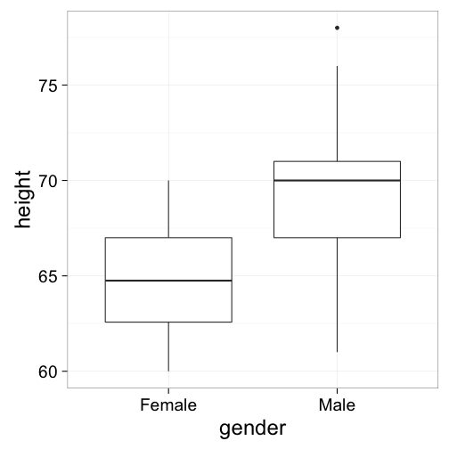

- \( y=1 \) are males
- \( y=0 \) are females.
- \( X \) are the heights

Can we estimate \[ \mbox{Pr}( y = 1 | X=x) \] ?

### Assessment

Define the following predictor

```r
X = round(dat$height)
```

Estimate and plot \( \,f(x) = \mbox{Pr}( y = 1 | X=x) \) for each \( x \).

### Regression

Based on this plot we try:

\[ f(x) = \mbox{Pr}( Y = 1 | X=x) = \beta_0 + \beta_1 x \]

Estimate \( \beta_0 \) and \( \beta_1 \) with least squares.

Our prediction rule will be: \[ \hat{f}(x) = \hat{\beta}_0+ \hat{\beta}_1 x \]

### Regression

Our estimates are

```
         term estimate std.error
1 (Intercept)   -4.917    0.6408
2      height    0.081    0.0095
```

Which implies the following predictions:

| truth | pred | height | f_hat |
| --- | --- | --- | --- |
| 1 | 1 | 69 | 0.68 |
| 0 | 0 | 65 | 0.36 |
| 0 | 1 | 67 | 0.52 |
| 0 | 1 | 69 | 0.68 |
| 0 | 0 | 63 | 0.19 |

### Confusion Matrix

```
          truth
prediction  0  1
         0 42 12
         1 26 67
```

```
Accuracy
    0.74
```

### Logistic Regression

We wrote down :

\[ f(x) = \mbox{Pr}( y = 1 | X=x) = \beta_0 + \beta_1 x \]

But expression on the right can be any real number while left is between 0 and 1.

General idea is to transform \( \mbox{Pr}( y = 1 | X=x) \):

\[ g(p) = \log \left( \frac{p}{1-p} \right) \]

### Logit Transformation

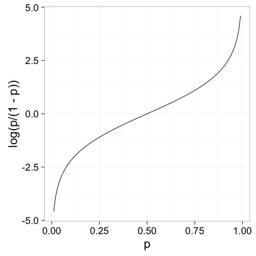

### Assessment

Remake the plot from the previous assessment but this time plot \( \,g(\hat{f}) \).

To avoid infinities, convert 1 to 0.99 and 0 to 0.01 and remove \( X>70 \)

### Logistic regression

Fits the following model:

\[ g\left\{ \mbox{E}(Y \mid X=x) \right\} = \beta_0 + \beta_1 x \]

Instead of least squares we compute the *maximum likelihood estimate* (MLE).

For about MLE in Statistical Theory course.

### Logistic Regression

```r
fit <- dat %>% filter(train) %>%
  glm(truth ~ height, data=.,
      family = "binomial")

dat <- dat %>%
  mutate(glm_f_hat =
           predict(fit, newdata = dat,
                   type="response")) %>%
  mutate(glm_pred=round(f_hat))
```

You can get help with `?glm` and `?predict.glm`

### Logistic Regression

Here are some predictions

| truth | glm_pred | height | glm_f_hat |
| --- | --- | --- | --- |
| 1 | 1 | 69 | 0.77 |
| 0 | 0 | 65 | 0.28 |
| 0 | 1 | 67 | 0.53 |
| 0 | 1 | 69 | 0.77 |
| 0 | 0 | 63 | 0.12 |
| 1 | 1 | 67 | 0.53 |
| 0 | 0 | 61 | 0.04 |
| 0 | 1 | 68 | 0.63 |
| 0 | 1 | 70 | 0.85 |
| 1 | 1 | 71 | 0.90 |

### Logistic versus Linear Regression

In this case we get practically the same answer:

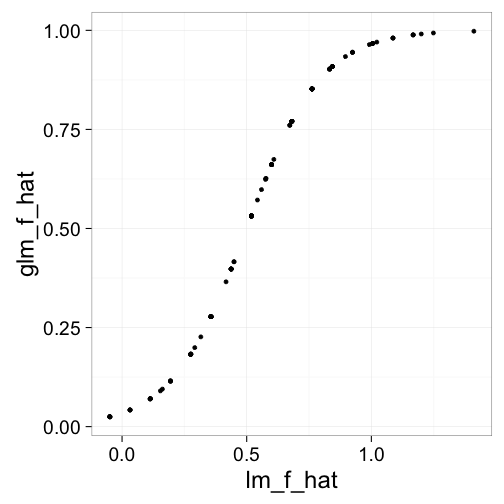

### Confusion Matrix

```
          truth
prediction  0  1
         0 42 12
         1 26 67
```

```
Accuracy
    0.74
```

### Bayes' Rule

In Machine Learning we refer to the prediction rule we would use if we knew

\[ \mbox{Pr}(Y=1 \mid \mathbf{X}=\mathbf{x}) \]

as *Bayes' rule*

This will be the best we can do.

But in practice we don't know this function.

Instead, we estimate it.

### Naive Bayes

Estimate conditional probabilities using Bayes' theorem.

With binary outcome and one continuous predictor we have:

\[ d(x) = \mbox{Pr}(Y=1|X=x) \] with \[ \mbox{Pr}(Y=1|X=x) = \frac{\pi p_{X|Y=1}(x)} {(1-\pi) p_{X|Y=0}(x) + \pi p_{X|Y=1}(x)} \]

\( p \) represents probability density function.

\( \pi \) is probability of \( Y=1 \)

### Naive Bayes

In this problem we can use the normal approximation in which case we estimate averages and standard deviations

We can estimate \( \pi \) like this

```r
pi <- filter(dat, train) %>% summarize(pi=mean(truth)) %>% .$pi
```

And the parameters of distribution function like this:

```r
params <- dat %>% filter(train) %>% group_by(gender) %>% summarize(avg = mean(height), sd = sd(height))
```

### Parameter Estimates

```r
pi
```

```
[1] 0.56
```

```r
params
```

```
Source: local data frame [2 x 3]

  gender   avg    sd
   (chr) (dbl) (dbl)
1 Female    65   2.8
2   Male    70   3.1
```

### Naive Bayes

The prediction rule is then:

```r
x <- dat$height
p0 <- dnorm(x, params$avg[1], params$sd[1])
p1 <- dnorm(x, params$avg[2], params$sd[2])
f_hat <- pi*p1/(pi*p1 + (1-pi)*p0)
```

### Naive Bayes

In this case it is very similar to regression approaches

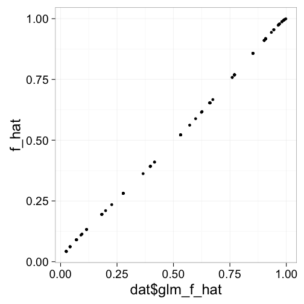

### Multiple Predictors

- All examples above include only one predictor
- We actually do not consider these machine learning challenges
- The techniques we described rarely work with more than one

### Digits

For illustration we will only try to distinguish 2 from 7.

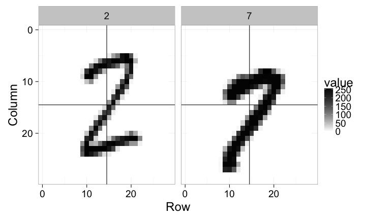

Two Feature Example: Percent of non-white pixels in upper left and lower right quadrants.

### Prediction Rule

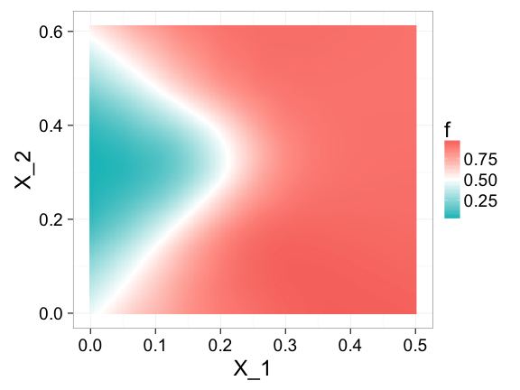

### Our data

We mimic a Machine Learning problem by sampling 1,000 digits

And splitting into training and test sets:

```r
library(caret)
inTrain <- createDataPartition(y = dat$label,
                               p=0.5)
train_set <- slice(dat, inTrain$Resample1)
test_set <- slice(dat, -inTrain$Resample1)
```

### Training Data

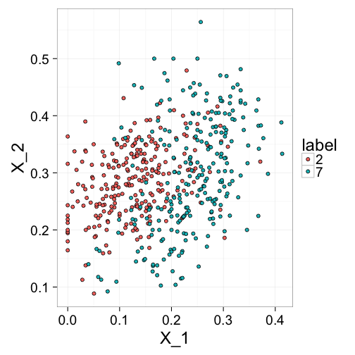

### Logistic Regression

Let's try the logistic regression model:

\[ g\left\{ \mbox{Pr}(Y=1 \mid X_1=x_1 , X_2 = x_2) \right\}= \beta_0 + \beta_1 x_1 + \beta_2 x_2 \]

which we fit it like this:

```r
fit <-  glm(y~X_1+X_2, data=train_set,
            family="binomial")
```

### Assessment

What type of function is the border between calling 0s and 1s? Hint: what kind of functions solves this

\[ f(x_1, x_2) = 0.5 \]

### Estimated Prediction Rule

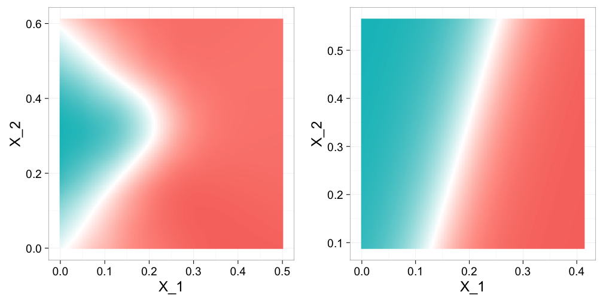

### Confusion Matrix

```
    truth
pred   0   1
   0 189  57
   1  60 194
```

```
Accuracy
    0.77
```

### Assessment

Can we use the empirical Bayes approach here? Why or what not?

If we do, notice we have to model the joint distributions \( f_{X_1,X_2 \mid Y=1} \) and \( f_{X_1,X_2 \mid Y=1} \). How may total parameters would this involve if we used the bivariate normal distribution?